# An Introduction to cosinet

Lanying Wei

2023-09-20

#### Package

cosinet 0.99.1

# 1 Introduction

`Cosinet` is an R package that aims to bridge the gap between differential co-expression network analysis and precision medicine by accurately quantifying the degree of rewiring of co-expression networks at the level of individual samples. Differential co-expression network analysis is a valuable approach for understanding the underlying mechanisms of disease and informing the development of personalized therapies, but current approaches typically measure an average differential network across multiple samples, making it difficult to apply in the field of precision medicine. Cosinet utilizes gene expression data to determine the degree of similarity between the gene co-expression patterns of a given sample and reference conditions within the context of a function-specific differential co-expression network. To obtain differential co-expression network, we provide R function for z-score-based differential co-expression analysis. Next, we calculate eigenvector centrality to get a ranked gene list, which represents the degree of hubness of each gene in the network. Based on the ranking, one can further perform gene set enrichment analysis (GSEA) to get enriched pathways, and use the core enrichment genes of a relevant pathway to form a function-specific differential co-expression sub-network. Finally, Cosinet scores can be calculated based on the specific sub-network. Here we show an example of using Cosinet to quantify the degree of rewiring with respect to the estrogen receptor (ER) response network for each estrogen receptor-positive (ER+) sample relative to the whole ER+ and estrogen receptor-negative (ER–) groups. ER+ breast cancer patients are typically treated with endocrine therapy. We demonstrate the quantified Cosinet scores significantly associate with survival outcomes in ER+ samples treated with endocrine therapy. The results highlight the potential of Cosinet to identify important differences in gene co-expression patterns between individual patients and to provide valuable insights for personalized treatment decisions.

# 2 Installation

To install the cosinet package, you can use the remotes package:

```r
# install Cosinet
if (!requireNamespace("remotes", quietly=TRUE))
    install.packages("remotes")
remotes::install_github("LanyingWei/cosinet")
```

# 3 Data analysis example

## 3.1 Prepare data

First we load the library and an exemplar dataset, and preprocess the expression data. The exemplar data is a subset of RNA-seq gene expression data from breast cancer patients. The full data is available in the Gene Expression Omnibus (GEO) repository under accession number GSE96058. The format of the expression value is log2(FPKM + 0.1) and was rounded to one digit to reduce data size.

```r
library(cosinet)
# get expression data
data(exprBC)
# get sample information
data(samplesBC)

# Check the order of the samples
all(colnames(exprBC) == samplesBC$title)
```

```
#> [1] TRUE
```

```r
# get ER status as condition
condition <- rep(NA, nrow(samplesBC))
condition[samplesBC$er_status %in% 0] <- "ER-Negative"
condition[samplesBC$er_status %in% 1] <- "ER-Positive"
condition <- factor(condition, levels = c("ER-Negative", "ER-Positive"))
# check the number of samples for each condition
table(condition)
```

```
#> condition
#> ER-Negative ER-Positive
#>         100         300
```

```r
# genes that are expressed in less than 20 samples for any condition are removed
# the data has already been transformed to log2(FPKM+0.01), so logTrans is set
# to FALSE
exprBC <- matPreprocess(exprMat = exprBC,
                        condition = condition,
                        minSample = 20,
                        minExp = log(0 + 0.01),
                        logTrans = FALSE)
```

```
#> 0 genes with expression value larger than -4.60517018598809 in less than 20 samples for any condition were removed.
#> 0 rows with duplicate gene names were removed.
#> Done.
```

## 3.2 Differential co-expression network

We then perform differential co-expression (DC) analysis to obtain a DC matrix. `Cosinet` provides a function for z-score-based DC analysis. A matrix derived with other methods, as long as it represents the level of differential co-expression of gene pairs between two conditions, can also be used for the downstream analysis.

```r
# calculate differential co-expression matrix
dcMat <- DCMat(exprMat = exprBC,
               condition = condition,
               corMethod = "spearman")
```

```
#> Calculating differential coexpression matrix for ER-Positive (n=300) versus ER-Negative (n=100) ...
#> Use Spearman correlation.
#> Calculating correlation matrix for the first condition...
#> Calculating correlation matrix for the second condition...
#> Fisher transformation...
#> Done.
```

## 3.3 Gene centrality

Next, we rank genes based on the eigenvector centrality of the full DC network. Eigenvector centrality measures node importance by summing its neighbors’ centralities. A node with many connections to other high-centrality nodes has high eigenvector centrality, while a node with few connections has a low centrality value. This allows identifying highly central genes that participate in a larger regulatory networks of certain in biological processes or pathways.

```r
# calculate gene centrality based on differential correlation matrix
geneCentrality <- eigenCentrality(mat = dcMat)
```

```
#> Use the absolute value of the matrix to proceed.
#> Total number of iterations: 14
#> Total differences between the last two iterations: 6.07318087875175e-07
```

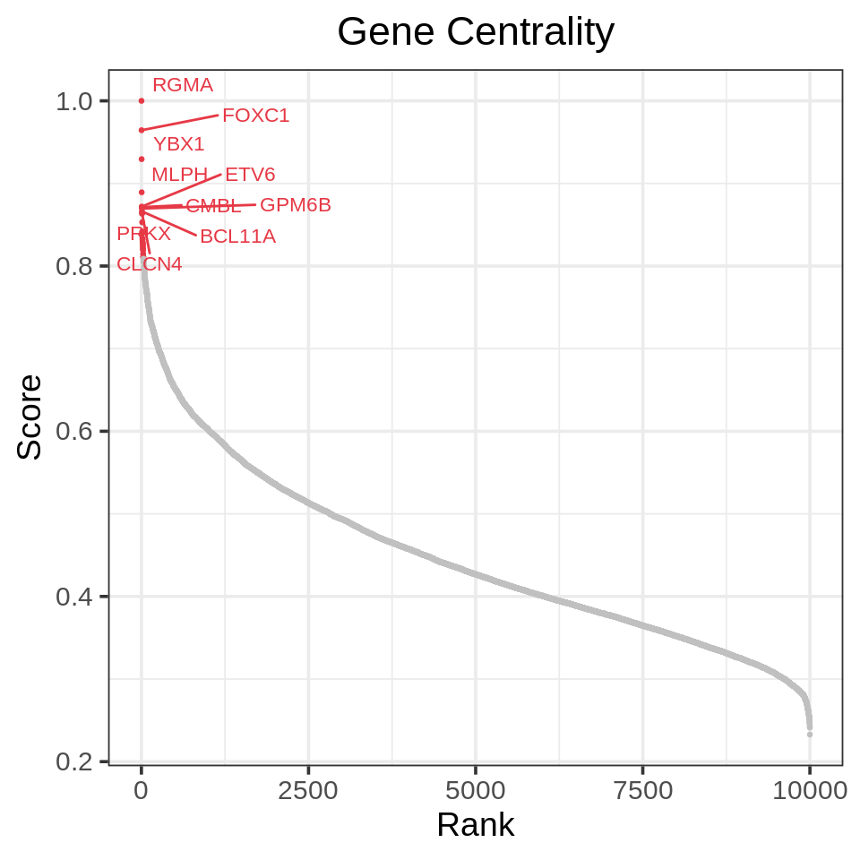

```r
# plot gene centrality rank plot
rankPlot(geneCentrality, nLabel = 10, nIQR = 2,
         main = "Gene Centrality")
```

## 3.4 Gene set enrichment analysis

Now that we have the gene centrality scores, we can use them as input to perform gene set enrichment analysis (GSEA) to obtain function-specific gene sets that are enriched for differentially co-expressed genes. Here we use *clusterProfiler* and MsigDB hallmark gene sets to perform GSEA as an example.

```r
# install packages
if (!require("clusterProfiler", quietly = TRUE)) {
    install.packages("clusterProfiler")
}
if (!require("msigdbr", quietly = TRUE)) BiocManager::install("msigdbr")
```

```r
# get hallmark gene sets
geneSets <- msigdbr::msigdbr(species = "Homo sapiens", category = "H")
geneSets <- geneSets[, c("gs_name", "gene_symbol")]

# run GSEA
# remember to set scoreType to "pos" since we only care about gene
# sets that are enriched at the top of the ranked list
library(clusterProfiler)
resGSEA <- GSEA(geneCentrality,
                TERM2GENE = geneSets,
                pvalueCutoff = 0.01,
                pAdjustMethod = "hochberg",
                seed = TRUE,
                scoreType = "pos",
                eps = 0)
```

```
#> preparing geneSet collections...
#> GSEA analysis...
#> leading edge analysis...
#> done...
```

```r
slot(resGSEA, "result")[, c(5, 7)]
```

```
#>                                                 NES     p.adjust
#> HALLMARK_E2F_TARGETS                       3.710026 2.457249e-21
#> HALLMARK_G2M_CHECKPOINT                    3.395055 1.581107e-16
#> HALLMARK_ESTROGEN_RESPONSE_EARLY           2.413858 1.555543e-05
#> HALLMARK_ESTROGEN_RESPONSE_LATE            2.255616 2.225594e-04
#> HALLMARK_MYC_TARGETS_V1                    2.159215 4.761462e-04
#> HALLMARK_EPITHELIAL_MESENCHYMAL_TRANSITION 2.042938 4.847846e-03
```

The third enriched gene set is “HALLMARK_ESTROGEN_RESPONSE_EARLY”, we use the core enrichment genes in this gene set to calculate the Cosinet score.

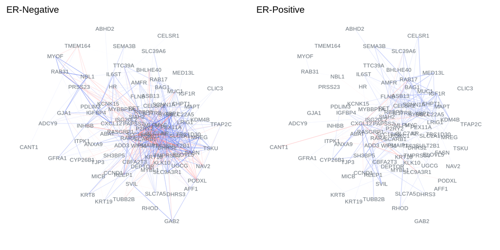

```r
# check GSEA plot for the "HALLMARK_ESTROGEN_RESPONSE_EARLY" gene set
# gseaplot(resGSEA,
#          geneSetID = slot(resGSEA, "result")$ID[3],
#          title = slot(resGSEA, "result")$Description[3])

# get core enrichment genes
genes <- slot(resGSEA, "result")$core_enrichment[3]
genes <- strsplit(genes, "\\/")[[1]]

# check DC plot for selected genes
# blue edges indicate positive correlation, red for negative correlation
# for more details, please see the manual page of the "DCPlot" function
p <- DCPlot(exprMat = exprBC,
            condition = condition,
            genes = genes,
            dcMat = dcMat,
            posDCCut = 3,
            negDCCut = -3,
            corMethod = "spearman",
            minimum = 0.3,
            labelCex = 0.6)
```

## 3.5 Get Cosinet score

With a set of interesting DC genes we can calculate the corresponding Cosinet scores based on the sub-network of these genes.

```r
# calculate Cosinet scores with given genes
# only gene pairs with a DC matrix value greater than 3 or less than -3 are
# included in the calculation
scoreMat <- getCosi(exprMat = exprBC,
                    bin = 0.1,
                    condition = condition,
                    genes = genes,
                    dcMat = dcMat,
                    weighted = TRUE,
                    posDCCut = 3,
                    negDCCut = -3,
                    threads = 2)
```

```
#> 4345 gene pairs that failed to meet the dcMat thresholds were removed from the Cosinet score calculation.
#> Performing calculation using 2 threads...
#> Weight each gene pair by absolute dcMat value.
#> 1326 gene pairs contributed to the final Cosinet score calculation.
```

```r
scoreMat[1:5, 1:5]
```

```
#>          Cosinet FOXC1_MLPH    FOXC1_AR FOXC1_XBP1 FOXC1_RARA
#> F2007 -1.5394158  -3.524117 -12.7195843   0.000000  1.3985606
#> F2974 -0.6898898   0.000000   0.1191198   0.000000  0.0000000
#> F2254 -0.2730822  -4.339976  -1.7730330  -2.497007  0.0000000
#> F458  -1.6644844   0.000000  -9.4818719   0.000000 -0.4234557
#> F2545 -1.8263924   0.000000  -2.6980936  -2.203242 -0.3257352
```

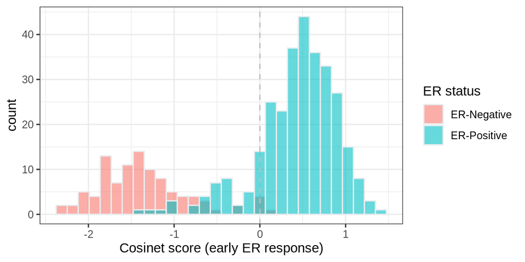

```r
# plot histogram for Cosinet scores
library(ggplot2)
data <- data.frame(Cosinet = scoreMat$Cosinet)
data <- cbind.data.frame(data, samplesBC)
ggplot(data, aes(x = Cosinet, fill = condition)) +
    geom_histogram(color="#e9ecef", alpha = 0.6,
                   position = 'identity', bins = 30) +
    guides(fill = guide_legend("ER status")) +
    geom_vline(xintercept = 0, linetype="dashed",
               color = "grey") +
    labs(x = "Cosinet score (early ER response)") +
    theme_bw()
```

## 3.6 Survival analysis

Finally, we perform survival analysis using Cosinet score and age as covariates.

```r
# install packages
if (!require("survival", quietly = TRUE)) install.packages("survival")
if (!require("survminer", quietly = TRUE)) install.packages("survminer")
```

```r
library(survival)
library(survminer)
# extract ER-positive samples
dataERPos <- data[data$er_status %in% 1, ]

# fit a Cox proportional hazards regression model with Cosinet score and age
survModel <- coxph(Surv(overall_survival_days,
                        overall_survival_event) ~ Cosinet +
                       age_at_diagnosis,
                   data = dataERPos)
summary(survModel)
```

```
#> Call:
#> coxph(formula = Surv(overall_survival_days, overall_survival_event) ~
#>     Cosinet + age_at_diagnosis, data = dataERPos)
#>
#>   n= 300, number of events= 38
#>
#>                      coef exp(coef) se(coef)      z Pr(>|z|)
#> Cosinet          -1.40031   0.24652  0.31416 -4.457 8.30e-06 ***
#> age_at_diagnosis  0.13058   1.13949  0.02221  5.879 4.12e-09 ***
#> ---
#> Signif. codes:  0 '***' 0.001 '**' 0.01 '*' 0.05 '.' 0.1 ' ' 1
#>
#>                  exp(coef) exp(-coef) lower .95 upper .95
#> Cosinet             0.2465     4.0565    0.1332    0.4563
#> age_at_diagnosis    1.1395     0.8776    1.0910    1.1902
#>
#> Concordance= 0.857  (se = 0.03 )
#> Likelihood ratio test= 64.53  on 2 df,   p=1e-14
#> Wald test            = 46.4  on 2 df,   p=8e-11
#> Score (logrank) test = 55.58  on 2 df,   p=9e-13
```

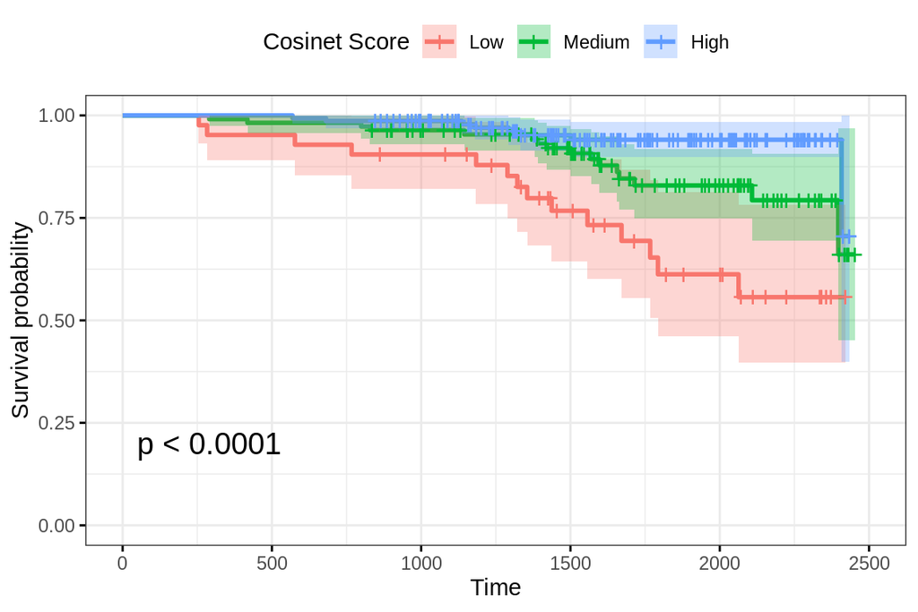

```r
# fit a survival curve for patients with different levels of Cosinet scores
# using the Kaplan-Meier method

dataERPos$CosinetScore <- NA
dataERPos$CosinetScore[dataERPos$Cosinet <= 0] <- "Low"
dataERPos$CosinetScore[dataERPos$Cosinet > 0 &
                           dataERPos$Cosinet <= 0.5] <- "Medium"
dataERPos$CosinetScore[dataERPos$Cosinet > 0.5] <- "High"

dataERPos$CosinetScore <- factor(dataERPos$CosinetScore,
                                 levels = c("Low", "Medium", "High"))

fit <- survfit(Surv(overall_survival_days,
                    overall_survival_event) ~ CosinetScore, data = dataERPos)

ggsurvplot(fit,
           data = dataERPos,
           conf.int = TRUE,
           pval = TRUE,
           legend.labs = c("Low", "Medium", "High"),
           legend.title = "Cosinet Score",
           ggtheme = theme_bw())
```